#### Github: https://github.com/rkoush/rkoush.github.io

# DATA601 (PCS1) FINAL TUTORIAL

# LA City Crime Data- An Analysis on victim likelihood

### Tutorial Created By: Rishi Koushik Sridharan

## **Credit**

**Data Provided by:** Los Angeles Police Department

**Dataset owner:** LAPD OpenData

**Source link:** http://data.lacity.org

**Licence:** CC0 1.0 Universal

# **Motivation**

This tutorial's main goal is to explore and analyze the **Los Angeles Crime Dataset**, provided by the Los Angeles Police Department (LAPD), in search of unique patterns and trends that can provide meaningful insights for the benefit of the general public and data-driven decision-making. Throughout the tutorial, the tutorial contains python code to crunch numbers, generate visuals and do mathematical modelling. To make things easier for the average reader, the tutorial includes observation and insights wherever necessary to highlight interesting patterns.

It is necessary to underline that this analysis is **fully apolitical** and does not try to make any assertions with respect to the political system, governance, or wider national comparisons. According to instructions from Los Angeles County, **inter-state comparisons** will not be made to maintain the focus on local crime patterns.

The idea behind this analysis is to let the **data speak for itself**, with the least assumptions and biases being introduced by the analysts. By so doing, we ensure that the insights derived are both **objective** and **data-driven**, thus fostering transparency and clarity in interpretation.

In this tutorial, we will cover:

- Part 1- Data Curation
- Part 2- Data Understanding
- Part 3- Missing Value Analysis and Data Treatment
- Part 4- Exploratory Data Analysis
- Part 5- Feature Engineering, Modelling and Inference
- Part 6- Conclusion

Let's start by importing some packages that we will be using throughout the tutorial.

```python
import requests as re # For scraping data
import io   # For string manipulation

#For data processing
import pandas as pd
import numpy as np
from datetime import date
from datetime import datetime

#For data visualization
import matplotlib.pyplot as plt
import seaborn as sns
import folium
from folium.plugins import FastMarkerCluster
from folium.plugins import MarkerCluster
from folium.plugins import HeatMap

# For data modelling or transformation
import statsmodels.api as sm
from sklearn.model_selection import train_test_split
from sklearn.preprocessing import OneHotEncoder, StandardScaler
from sklearn.preprocessing import LabelEncoder
from sklearn.metrics import confusion_matrix, ConfusionMatrixDisplay

import warnings
warnings.filterwarnings('ignore')
```

# **Part 1- Data Curation**

Next, we scrape the data from the source webpage. We use the requests library's get() function to fetch the data. The data portal has a limit of 1000 rows per request to avoid DDoS attacks or overwhelm their servers. Hence, we use a loop with the offset parameter to continuosly retrieve 1000 rows at a time and append them to the list. We then concatenate all the lists into a pandas DataFrame.

Using a pandas dataframe is the most effective and easy way to do data pre-processing.

[figure not shown]

```python
# Base URL of the dataset API
base_url = "https://data.lacity.org/resource/2nrs-mtv8.csv"

# Function to fetch data
def fetch_data(base_url, offset):
    params = {
        "$offset": offset,
    }
    response = re.get(base_url, params=params)
    if response.status_code == 200:
        return response.text
    else:
        print(f"Failed to fetch data: {response.status_code}")
        return None

# Initialize variables
all_data = []
offset = 0
chunk_size = 1000  # Default chunk size of the API

while True:
    # print(f"Fetching data with offset {offset}...")
    data_chunk = fetch_data(base_url, offset)
    if not data_chunk:
        break

    # Convert chunk to DataFrame using io.StringIO
    chunk_df = pd.read_csv(io.StringIO(data_chunk))

    # Break the loop if no more data is returned
    if chunk_df.empty:
        break
    all_data.append(chunk_df)
    offset += chunk_size

# Concatenate all chunks into a single DataFrame
if all_data:
    full_dataset = pd.concat(all_data, ignore_index=True)
else:
    print("No data fetched.")

# Save to a CSV if needed
full_dataset.to_csv("data.csv", index=False)
```

**NOTE**

Now that we have stored the data in a CSV format, it is much easier to read it for future runs. We do not want to be scraping the data every time we want to run some analysis on the notebook, so converting it to a CSV format and storing it is the best option. You only need to run the above cell once and then you can run the cell below for all future iterations.

```python
full_dataset = pd.read_csv(f'/content/sample_data/data.csv')
```

```python
data = full_dataset.copy()
```

# **Part 2- Data Understanding**

```python
data.head(3)
```

|  | dr_no | date_rptd | date_occ | time_occ | area | area_name | rpt_dist_no | part_1_2 | crm_cd | crm_cd_desc | ... | status | status_desc | crm_cd_1 | crm_cd_2 | crm_cd_3 | crm_cd_4 | location | cross_street | lat | lon |
| --- | --- | --- | --- | --- | --- | --- | --- | --- | --- | --- | --- | --- | --- | --- | --- | --- | --- | --- | --- | --- | --- |
| 0 | 190326475 | 2020-03-01T00:00:00.000 | 2020-03-01T00:00:00.000 | 2130 | 7 | Wilshire | 784 | 1 | 510 | VEHICLE - STOLEN | ... | AA | Adult Arrest | 510.0 | 998.0 | NaN | NaN | 1900 S LONGWOOD AV | NaN | 34.0375 | -118.3506 |
| 1 | 200106753 | 2020-02-09T00:00:00.000 | 2020-02-08T00:00:00.000 | 1800 | 1 | Central | 182 | 1 | 330 | BURGLARY FROM VEHICLE | ... | IC | Invest Cont | 330.0 | 998.0 | NaN | NaN | 1000 S FLOWER ST | NaN | 34.0444 | -118.2628 |
| 2 | 200320258 | 2020-11-11T00:00:00.000 | 2020-11-04T00:00:00.000 | 1700 | 3 | Southwest | 356 | 1 | 480 | BIKE - STOLEN | ... | IC | Invest Cont | 480.0 | NaN | NaN | NaN | 1400 W 37TH ST | NaN | 34.0210 | -118.3002 |

3 rows × 28 columns

```python
data.info()
```

```
<class 'pandas.core.frame.DataFrame'>
RangeIndex: 991360 entries, 0 to 991359
Data columns (total 28 columns):
 #   Column          Non-Null Count   Dtype
---  ------          --------------   -----
 0   dr_no           991360 non-null  int64
 1   date_rptd       991360 non-null  object
 2   date_occ        991360 non-null  object
 3   time_occ        991360 non-null  int64
 4   area            991360 non-null  int64
 5   area_name       991360 non-null  object
 6   rpt_dist_no     991360 non-null  int64
 7   part_1_2        991360 non-null  int64
 8   crm_cd          991360 non-null  int64
 9   crm_cd_desc     991360 non-null  object
```

[output cut: 20 more lines]

```python
data[['area','vict_age']].describe(percentiles=[0.1,0.2,0.3,0.4,0.5,0.6,0.7,0.8,0.9])
```

|  | area | vict_age |
| --- | --- | --- |
| count | 991360.000000 | 991360.000000 |
| mean | 10.654731 | 28.922507 |
| std | 6.124148 | 22.003915 |
| min | 1.000000 | -4.000000 |
| 10% | 2.000000 | 0.000000 |
| 20% | 4.000000 | 0.000000 |
| 30% | 6.000000 | 19.000000 |
| 40% | 8.000000 | 25.000000 |
| 50% | 11.000000 | 30.000000 |
| 60% | 13.000000 | 35.000000 |
| 70% | 15.000000 | 41.000000 |
| 80% | 17.000000 | 48.000000 |
| 90% | 19.000000 | 58.000000 |
| max | 21.000000 | 120.000000 |

### Overview of the LA Crime Dataset

The **Los Angeles Crime Dataset** is a cumulative description of crimes that have been provided through the **Los Angeles Police Department (LAPD)**. It varies with years and includes a great detail with respect to crimes being reported in different regions in greater Los Angeles. Each row points to a unique report related to crime, but various columns depict several details related to crime, location, victims of the crime, and respective metadata. Below is summarized each column from the original data:

Key Columns and Their Descriptions

1. **`dr_no`**: This is the unique identifier for every crime report. It's the primary key for this data set, ensuring that no record is conflated with another.
2. **`date_rptd`**: The date of the crime report. Note that in some cases, this may not be the actual date the crime occurred.
3. **`date_occ`**: This is the date the crime actually occurred. This allows for temporal analyses of crime patterns and trends.
4. **`time_occ`**: Time the crime occurred in military time, for example, 1330 for 1:30 PM. This could be useful if there is any pattern for crimes occurring during specific times of the day.
5. **`area`**: A numeric code for LAPD-defined area or division where the crime occurred.
6. **`area_name`**: The name of the division corresponding to `area`, such as "Hollywood", "Central". This gives more interpretability to the geographic location of the crime.
7. **`rpt_dist_no`**: This is a numeric representation of the reporting district number, and therefore represents a finer geographic subdivision inside an LAPD area that will enable crime data analysis in a very specific and targeted location.
8. **`part_1_2`**: Numeric code indicating whether crime was Part 1 (serious crime) or Part 2 (not serious crime).
9. **`crm_cd`**: Short numeric code showing what type of crime committed; used for quickly grouping crimes.
10. **`crm_cd_desc`**: The description of the crime type associated with the `crm_cd` code; for example, "Robbery," "Burglary," "Assault with a Deadly Weapon." In such a way, it gives clarity about the offense nature.
11. **`mocodes`**: A string or numeric code describing the modus operandi (MO) or method used to commit the crime. It can contain several codes separated by commas when there are multiple MOs in one crime.
12. **`vict_age`**: The age of the victim in the reported crime. This allows for demographic analyses to identify victimization patterns by age.
13. **`vict_sex`**: The sex of the victim, recorded as "M" (Male), "F" (Female), or "X" (Unknown).
14. **`vict_descent`**: The descent or ethnic background of the victim (e.g., "White," "Black," "Hispanic"). This allows for demographic and equity-based analysis.
15. **`premis_cd`**: A numeric code describing the type of premises where the crime occurred--for example, residence, business, public place.
16. **`premis_desc`**: A textual description of the premises corresponding to `premis_cd`--like "Apartment," "Street," "Parking Lot".
17. **`weapon_used_cd`**: a code indicating what kind of weapon was used during this crime, if any.
18. **`weapon_desc`**: A textual description of the weapon corresponding to `weapon_used_cd`--for example, "Knife," "Firearm".
19. **`status`**: A code indicating the status of the case, such as "AA" for Arrest Adult and "IC" for Investigation Continued Case.
20. **`status_desc`**: Text description of the status code, which provides clarity of the resolution/state of the case.
21. **`crm_cd_1`, `crm_cd_2`, `crm_cd_3`, `crm_cd_4`**: Additional columns for crime codes associated with the record in cases of multiple offenses.
22. **`location`**: Full text description of the crime location.
23. **`cross_street`**: Cross streets of address where the crime was committed; provides more granular location information.
24. **`lat`**: Latitude of the location where the crime occurred; allows for geospatial mapping of the data points.
25. **`lon`**: Longitude of the location of the crime; pairs with the `lat` column above for spatial analysis.

### Purpose of the Dataset

This dataset forms a good basis of performing crime trend analysis in Los Angeles. It can be used to determine crime hotspots, explore frequency and distribution of different crimes, analyse victim demographics etc.

The dataset has a good potential for actionable insights that could be helpful in law enforcement and community safety.

# **Part 3- Missing Value Analysis and Data Treatment**

[figure not shown]

Let's start by calculating the percentage of missing values in each column. This will help us find an appropriate solution for treating these missing values.

```python
(data.isnull().sum()/ len(full_dataset)) * 100
```

|  | 0 |
| --- | --- |
| dr_no | 0.000000 |
| date_rptd | 0.000000 |
| date_occ | 0.000000 |
| time_occ | 0.000000 |
| area | 0.000000 |
| area_name | 0.000000 |
| rpt_dist_no | 0.000000 |
| part_1_2 | 0.000000 |
| crm_cd | 0.000000 |
| crm_cd_desc | 0.000000 |
| mocodes | 14.977808 |
| vict_age | 0.000000 |
| vict_sex | 14.285224 |
| vict_descent | 14.286233 |
| premis_cd | 0.001614 |
| premis_desc | 0.057295 |
| weapon_used_cd | 67.212516 |
| weapon_desc | 67.212516 |
| status | 0.000101 |
| status_desc | 0.000000 |
| crm_cd_1 | 0.001110 |
| crm_cd_2 | 93.037444 |
| crm_cd_3 | 99.766785 |
| crm_cd_4 | 99.993847 |
| location | 0.000000 |
| cross_street | 84.714029 |
| lat | 0.000000 |
| lon | 0.000000 |

**dtype:** float64

Let's clean the data up so that our analysis is much cleaner

```python
# data.drop(columns=['Unnamed: 0'], inplace=True)
data.drop(columns=['cross_street','mocodes'], inplace=True)
data.vict_sex.fillna('X', inplace=True)
data.loc[data['vict_sex'] == '-', 'vict_sex'] = 'X'
data.vict_descent.fillna('X', inplace=True)
data.vict_age = data['vict_age'].apply(lambda x: x if x>=0 else 0)
```

Now, the victim descent and sex columns are in codes. We want to expand them so that our analysis becomes understandable. These code mappings are provided in the LA City data source website.

```python
# We map the codes to their corresponding descriptions
descent_mapping = {
    'A': 'Other Asian',
    'B': 'Black',
    'C': 'Chinese',
    'D': 'Cambodian',
    'F': 'Filipino',
    'G': 'Guamanian',
    'H': 'Hispanic/Latin/Mexican',
    'I': 'American Indian/Alaskan Native',
    'J': 'Japanese',
    'K': 'Korean',
    'L': 'Laotian',
    'O': 'Other',
    'P': 'Pacific Islander',
    'S': 'Samoan',
    'U': 'Hawaiian',
    'V': 'Vietnamese',
    'W': 'White',
    'X': 'Unknown',
    'Z': 'Asian Indian'
}
data['vict_descent'] = data['vict_descent'].map(descent_mapping)

data['vict_descent'].fillna('Unknown', inplace=True)

sex_mapping = {
    'F': 'Female',
    'M': 'Male',
    'H': 'Prefer not to say',
    'X': 'Unknown'
}
data['vict_sex'] = data['vict_sex'].map(sex_mapping)
```

```python
data['premis_desc'].fillna('Unknown', inplace=True)
```

```python
data['crime_count']=0
data['crime_count'] += data['crm_cd_1'].notna().astype(int)
data['crime_count'] += data['crm_cd_2'].notna().astype(int)
data['crime_count'] += data['crm_cd_3'].notna().astype(int)
data['crime_count'] += data['crm_cd_4'].notna().astype(int)
data['crime_count'].value_counts()
```

| crime_count | count |
| --- | --- |
| 1 | 922347 |
| 2 | 66701 |
| 3 | 2251 |
| 4 | 61 |

**dtype:** int64

```python
data.drop(columns=['crm_cd_1', 'crm_cd_2', 'crm_cd_3', 'crm_cd_4'], inplace=True)
```

```python
data['date_occ'] = pd.to_datetime(data['date_occ'])
data['date_occ'] = data['date_occ'].dt.date
data['date_rptd'] = pd.to_datetime(data['date_rptd'])
data['date_rptd'] = data['date_rptd'].dt.date
print("The date range is : ", data['date_occ'].min(), "to", data['date_occ'].max())
```

```
The date range is :  2020-01-01 to 2024-12-09
```

Let's create some month-year column for crime occured date and crime reported date so that we can use it for time series visualizations.

```python
data['crime_occured_month_year'] = data['date_occ'].apply(lambda x: x.strftime('%Y-%m'))
data['crime_reported_month_year'] = data['date_rptd'].apply(lambda x: x.strftime('%Y-%m'))
```

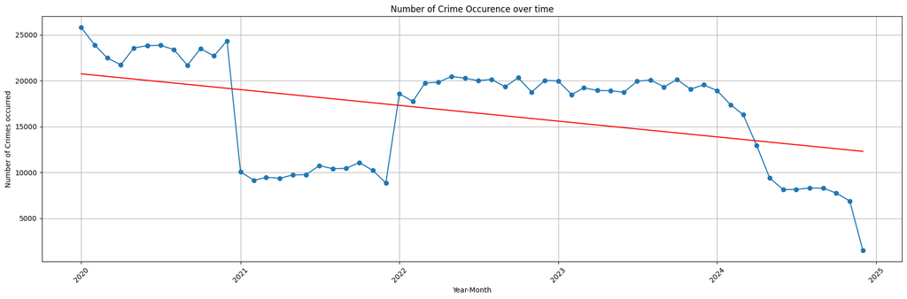

```python
monthly_crime_counts = data.groupby('crime_occured_month_year').size()
monthly_crime_counts.index = pd.to_datetime(monthly_crime_counts.index)

x = monthly_crime_counts.index.map(lambda date: date.toordinal())  # Convert datetime to numeric
y = monthly_crime_counts.values

# Fitting an Ordinary Least Square regression line
X = sm.add_constant(x)  # Add constant for intercept
model = sm.OLS(y, X).fit()  # Fitting OLS model
y_pred = model.predict(X)  # Predicted values

plt.figure(figsize=(18, 6))
plt.plot(monthly_crime_counts.index, monthly_crime_counts.values, marker='o')
plt.plot(monthly_crime_counts.index, y_pred, color='red', label='OLS Regression Line')  # Regression line
plt.xticks(rotation=45)
plt.xlabel('Year-Month')
plt.ylabel('Number of Crimes occurred')
plt.title('Number of Crime Occurence over time')
plt.grid()
plt.tight_layout()
plt.show()
```

## **Observation**

- There is a **sharp drop in crime in 2021** followed by a **significant increase in 2022**, suggesting potential data discrepancies.
- While the data source (LA City's open data portal) claims high accuracy, such fluctuations make **time series analysis unreliable**.

**Unless Batman was active in LA during 2021**, the sharp decline in crime is most likely due to data inconsistencies.

[figure not shown]

Let's confirm this fact with the trend of crimes reported through the 4 years. If we see a drop in the number of reports in 2021 and a subsequent increase in 2022, we can safely assume that the enitre 2021 data might have issues. If we don't see such a pattern, this issue might just be with the "Date Occurred" column in the table.

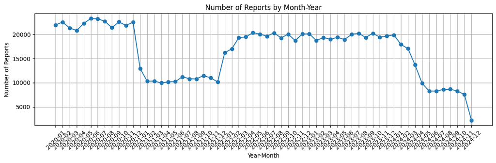

```python
monthly_report_counts = data.groupby('crime_reported_month_year').size()
monthly_report_counts.index = monthly_report_counts.index.astype(str)
monthly_crime_counts = monthly_report_counts.sort_index()
plt.figure(figsize=(12, 4))
plt.plot(monthly_report_counts.index, monthly_report_counts.values, marker='o')
plt.xticks(rotation=45)
plt.xlabel('Year-Month')
plt.ylabel('Number of Reports')
plt.title('Number of Reports by Month-Year')
plt.grid()
plt.tight_layout()
plt.show()
```

Now that we have confirmed that enitire 2021's data is faulty, let's filter the date from 2022 to 2023 so that we get a clearer picture. We also exclude 2024 from the data because we again see a decrease in crime. This is likely due to the fact that the data is not up-to-date for the current year.

```python
data_filt = data[((data['date_occ'] >= date(2022, 1, 1)) & (data['date_occ'] <= date(2023, 12, 31)))]
```

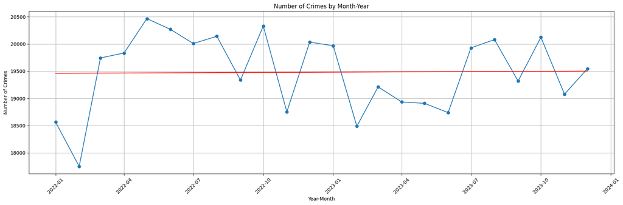

```python
monthly_crime_counts_filt = data_filt.groupby('crime_occured_month_year').size()
monthly_crime_counts_filt.index = pd.to_datetime(monthly_crime_counts_filt.index)

x = monthly_crime_counts_filt.index.map(lambda date: date.toordinal())  # Convert datetime to numeric
y = monthly_crime_counts_filt.values

# Fitting an Ordinary Least Squares regression line
X = sm.add_constant(x)  # Constant for the intercept
model = sm.OLS(y, X).fit()  # Fitting the OLS model
y_pred = model.predict(X)  # Predicting values

plt.figure(figsize=(18, 6))
plt.plot(monthly_crime_counts_filt.index, monthly_crime_counts_filt.values, marker='o')
plt.plot(monthly_crime_counts_filt.index, y_pred, color='red', label='OLS Regression Line')  # Plotting the OLS Regression line
plt.xticks(rotation=45)
plt.xlabel('Year-Month')
plt.ylabel('Number of Crimes')
plt.title('Number of Crimes by Month-Year')
plt.grid()
plt.tight_layout()
plt.show()
```

Looking at the trend of crime over the 2 years (2022, 2023), we see that the trend line is linear with no upward or downward trend. Although certain months show a drop in crime, there are other months with a similar rise in crime. Hence, there is no upward or downward trend in the 2 years.

```python
victim_descent_percentage = (
    data_filt['vict_descent']
    .value_counts(normalize=True) * 100  # Normalize=True gives proportions, multiplying by 100 for percentages
)
victim_descent_df = victim_descent_percentage.reset_index()
victim_descent_df.columns = ['Victim Descent', 'Percentage']
```

# **Part 4- Exploratory Data Analysis**

### Crime Hotspots

```python
crime_data = data_filt.dropna(subset=['lat', 'lon'])  # Remove rows with NULL lat/lon

# Create a folium map centered around the mean latitude and longitude
map_center = [crime_data['lat'].mean(), crime_data['lon'].mean()]
crime_map = folium.Map(location=map_center, zoom_start=12)

# Use FastMarkerCluster from folium for the map visual
FastMarkerCluster(data=list(zip(crime_data['lat'], crime_data['lon']))).add_to(crime_map)

# Display the map
crime_map
```

Make this Notebook Trusted to load map: File -> Trust Notebook

[interactive chart not shown]

This provides us with an interesting map visual that can be used to locate crime hotspots. The data provides us with Latitudes and Longitudes that are accurate to 100 city blocks to protect the privacy of citizens. So, the visual does not show very precise locations of crime, but an overview of the crime hotspots can still be observed from this plot.

### Crime Status (Investigation ongoing, arrests etc)

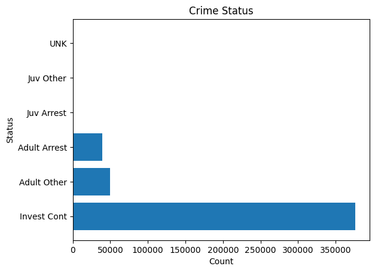

```python
status_count = data_filt.status_desc.value_counts()
plt.barh(status_count.index, status_count.values)
plt.xlabel("Count")
plt.ylabel("Status")
plt.title("Crime Status")
plt.show()
```

This is an interesting trend. We can see that over 75% of the crimes have continued investigation (This is the default value when an arrest or other is not performed). We can see that less than 12% of the crimes commited involves arrest.

### Victim Demographics

Before we start looking at victim demographics, we need to understand the population demographics of Los Angeles so that we do not move to false conclusions. We will require the Age, Sex and Descent demographics of people in Los Angeles

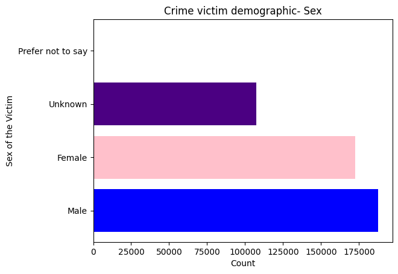

```python
vict_sex_counts = data_filt.vict_sex.value_counts()
plt.barh(vict_sex_counts.index, vict_sex_counts.values, color=['Blue', 'Pink', 'Indigo']) # Horizontal Bar Chart
plt.xlabel("Count")
plt.ylabel("Sex of the Victim")
plt.title("Crime victim demographic- Sex")
plt.show()
```

## **Observation**

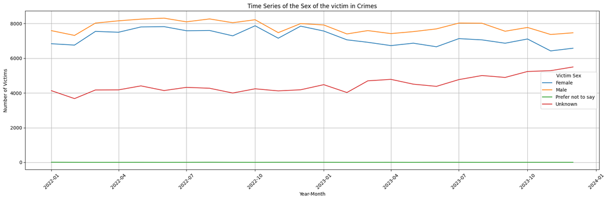

```python
data_filt['month_year'] = data_filt['date_occ'].apply(lambda x: x.replace(day=1))
sex_trends = data_filt.groupby(['month_year', 'vict_sex']).size().unstack(fill_value=0)
plt.figure(figsize=(18, 6))

# Plotting each "Sex" with different lines in a lineplot
for sex in sex_trends.columns:
    plt.plot(sex_trends.index, sex_trends[sex], label=sex)

plt.xticks(rotation=45)
plt.xlabel('Year-Month')
plt.ylabel('Number of Victims')
plt.title('Time Series of the Sex of the victim in Crimes')
plt.legend(title="Victim Sex")
plt.grid()
plt.tight_layout()
plt.show()
```

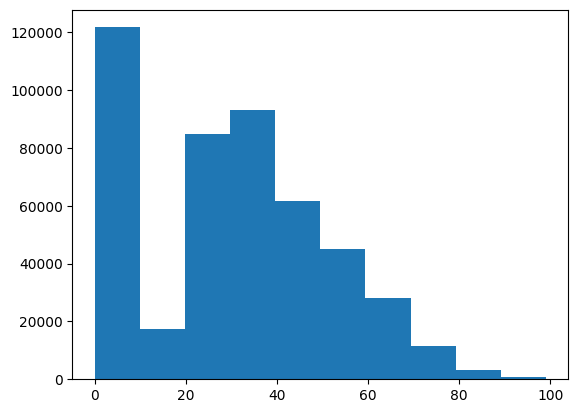

```python
plt.hist(data_filt.vict_age)
plt.show()
```

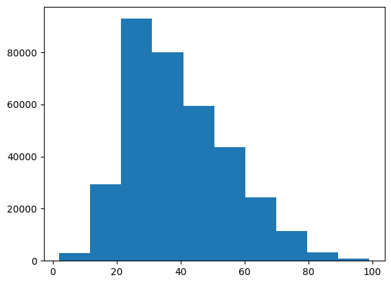

```python
plt.hist(data_filt[data_filt['vict_age']>0].vict_age)
plt.show()
```

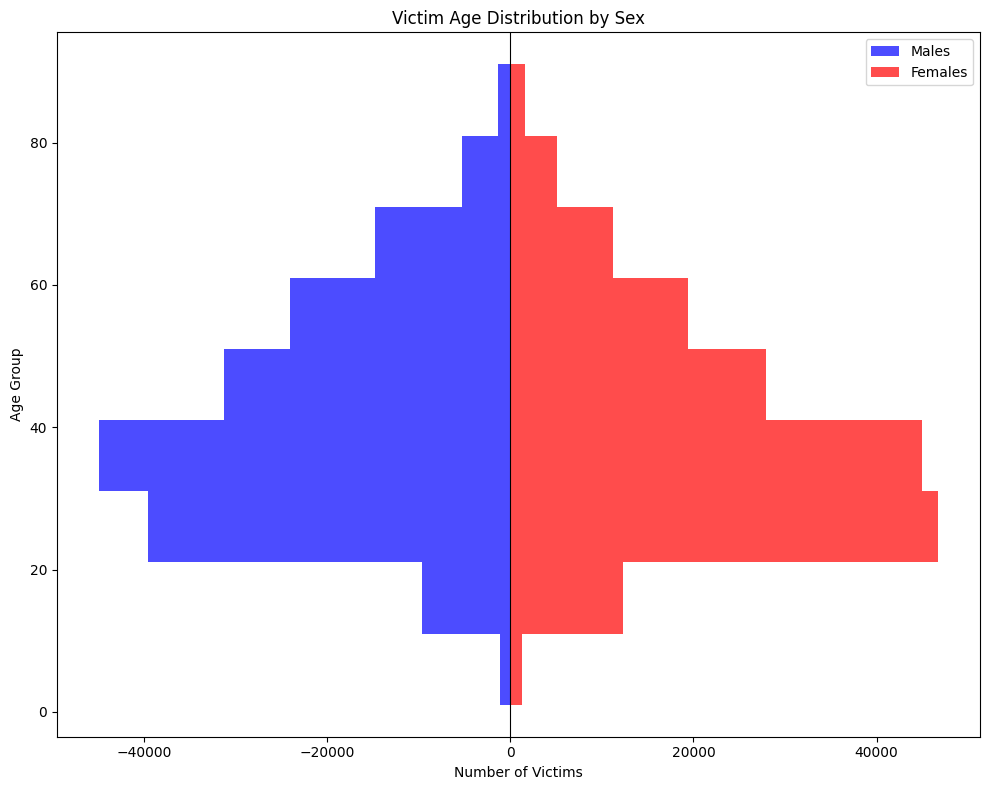

```python
import matplotlib.pyplot as plt
import numpy as np

# Filter data to exclude "Unknown" from vict_sex
data_filtered = data_filt[data_filt['vict_sex'] != "Unknown"]

# Separate data by sex
male_ages = data_filtered[data_filtered['vict_sex'] == "Male"]['vict_age']
female_ages = data_filtered[data_filtered['vict_sex'] == "Female"]['vict_age']

# Define bins for age groups
bins = np.arange(1, 101, 10)  # Buckets for age: 0-10, 10-20, ..., 90-100

# Calculate histogram counts for both genders
male_hist, _ = np.histogram(male_ages, bins=bins)
female_hist, _ = np.histogram(female_ages, bins=bins)

# Mirror male histogram by making values negative
male_hist = -male_hist

# Plot the mirrored histograms using barh
plt.figure(figsize=(10, 8))
plt.barh(bins[:-1] + 5, male_hist, color='blue', alpha=0.7, height=10, label='Males')
plt.barh(bins[:-1] + 5, female_hist, color='red', alpha=0.7, height=10, label='Females')

# Add labels and formatting
plt.axvline(0, color='black', linewidth=0.8)  # Vertical line at x=0
plt.xlabel('Number of Victims')
plt.ylabel('Age Group')
plt.title('Victim Age Distribution by Sex')
plt.legend()
plt.tight_layout()
plt.show()
```

***NOTE: Although the x-axis shows negative values for the Male sex, the count should still be considered in positive numbers. This was done to represent both genders in the same graph, but the information should not be misconstrued.***

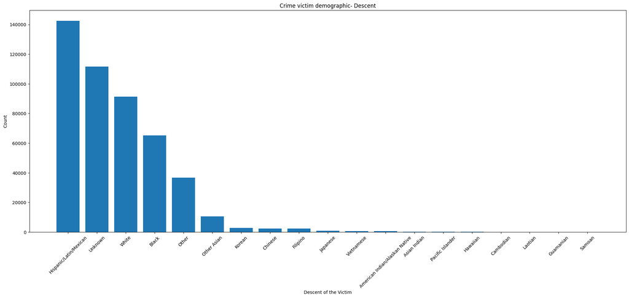

```python
vict_descent_counts = data_filt.vict_descent.value_counts()
plt.figure(figsize=(24,9))
plt.bar(vict_descent_counts.index, vict_descent_counts.values)
plt.xticks(rotation=45)
plt.xlabel("Descent of the Victim")
plt.ylabel("Count")
plt.title("Crime victim demographic- Descent")
plt.show()
```

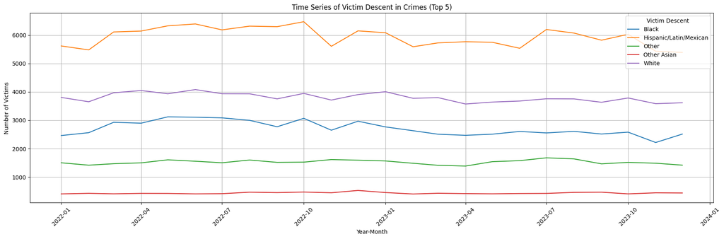

```python
top_descents = (data_filt[data_filt['vict_descent'] != "Unknown"].groupby('vict_descent').size().nlargest(5).index)
top_descents_data = data_filt[data_filt['vict_descent'].isin(top_descents)]
top_descents_data['month_year'] = top_descents_data['date_occ'].apply(lambda x: x.replace(day=1))
descent_trends = (top_descents_data.groupby(['month_year', 'vict_descent']).size().unstack(fill_value=0))
plt.figure(figsize=(18, 6))
for descent in descent_trends.columns:
    plt.plot(descent_trends.index, descent_trends[descent],  label=descent)

plt.xticks(rotation=45)
plt.xlabel('Year-Month')
plt.ylabel('Number of Victims')
plt.title('Time Series of Victim Descent in Crimes (Top 5)')
plt.legend(title="Victim Descent")
plt.grid()
plt.tight_layout()
plt.show()
```

Source: https://www.census.gov/quickfacts/fact/table/losangelescitycalifornia/PST045223?utm_source=chatgpt.com

```python
# Filtering the victim descent for the top 10 categories
filter_descents = ['Black', 'Hispanic/Latin/Mexican', 'Other', 'Other Asian', 'White', 'Korean', 'Chinese', 'Filipino', 'Japanese', 'Vietnamese']
victim_descent_df = victim_descent_df[victim_descent_df['Victim Descent'].isin(filter_descents)]

# Dictionary of population figures for the 5 categories. Approximate figures from various reliable sources
population_data = {
    'Black': 9.0,
    'Hispanic/Latin/Mexican': 48.2,
    'Other': 2.2,
    'Other Asian': 5.1,
    'White': 28.1,
    'Korean': 1.2,
    'Chinese': 1.8,
    'Filipino': 1.5,
    'Japanese': 0.9,
    'Vietnamese': 0.5
}

victim_descent_df['Population Percentage'] = victim_descent_df['Victim Descent'].map(population_data)

print(victim_descent_df)
```

```
            Victim Descent  Percentage  Population Percentage
0   Hispanic/Latin/Mexican   30.479185                   48.2
2                    White   19.526483                   28.1
3                    Black   13.929614                    9.0
4                    Other    7.829927                    2.2
5              Other Asian    2.240330                    5.1
6                   Korean    0.574893                    1.2
7                  Chinese    0.494477                    1.8
8                 Filipino    0.492766                    1.5
9                 Japanese    0.164255                    0.9
10              Vietnamese    0.124047                    0.5
```

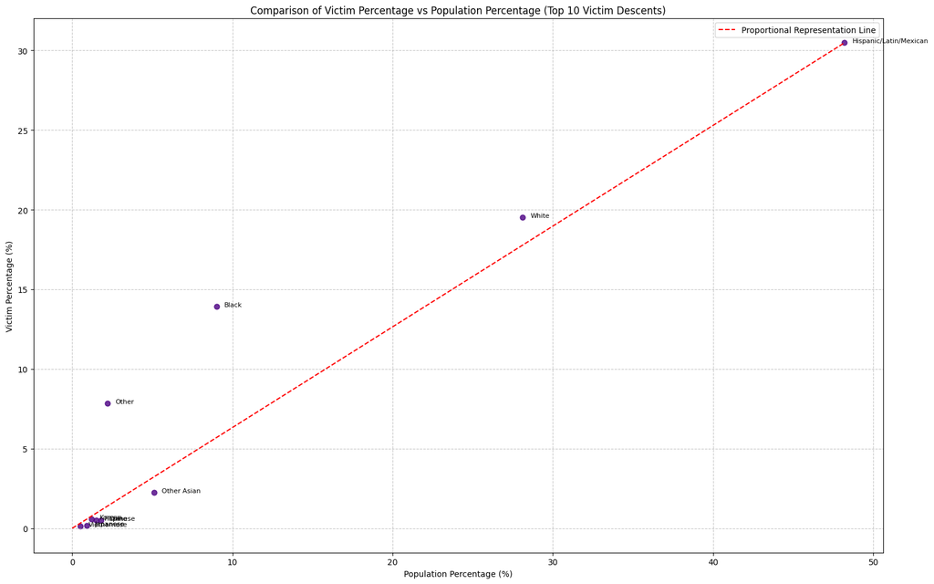

```python
plt.figure(figsize=(16, 10))
plt.scatter(
    victim_descent_df['Population Percentage'],
    victim_descent_df['Percentage'],
    color='indigo', s=40, alpha=0.8
)

# Add labels for each point
for i, row in victim_descent_df.iterrows():
    plt.text(
        row['Population Percentage'] + 0.5,  # Slight offset for readability
        row['Percentage'],
        row['Victim Descent'],
        fontsize=8
    )

# Add reference line where Population Percentage == Victim Percentage
plt.plot(
    [0, max(victim_descent_df['Population Percentage'])],
    [0, max(victim_descent_df['Percentage'])],
    color='red', linestyle='--', label='Proportional Representation Line'
)

# Customize the plot
plt.xlabel('Population Percentage (%)')
plt.ylabel('Victim Percentage (%)')
plt.title('Comparison of Victim Percentage vs Population Percentage (Top 10 Victim Descents)')
plt.grid(True, linestyle='--', alpha=0.7)
plt.legend()
plt.tight_layout()
plt.show()
```

## **Observations**

The plot visualizes the comparison between the **percentage of victims** from each descent group and their corresponding **percentage of the population** in Los Angeles City. The reference line represents **proportionality**, where:

1. **On the Reference Line**:  
   If a descent's data point lies on the reference line, it signifies that the percentage of victims from that community is **proportionate to their population percentage**.
2. **Below the Reference Line**:  
   If a descent's data point falls below the line, it indicates that the community is **underrepresented** as victims compared to their population size.
3. **Above the Reference Line**:  
   If a descent's data point lies above the line, it signifies that the community is being **disproportionately targeted**. The farther a point lies above the line, the greater the disparity.

### **Key Insights**

# **Part 5- Feature Engineering, Modelling and Model Inference**

[figure not shown]

```python
data_filt['day_of_week'] = pd.to_datetime(data_filt['date_occ']).dt.dayofweek  # 0=Monday, 6=Sunday
data_filt['hour'] = data_filt['time_occ'] // 100  # Extracting the hour assuming that time_occ is in HHMM format

def time_of_day(hour):
    if 6 <= hour < 12:
        return 'Morning'
    elif 12 <= hour < 18:
        return 'Afternoon'
    elif 18 <= hour < 24:
        return 'Evening'
    else:
        return 'Night'

data_filt['time_bin'] = data_filt['hour'].apply(time_of_day)
print(data_filt[['day_of_week', 'hour', 'time_bin']].head())
```

```
        day_of_week  hour   time_bin
337381            1    12  Afternoon
337519            5    21    Evening
338542            3    11    Morning
339180            0    18    Evening
339315            2     6    Morning
```

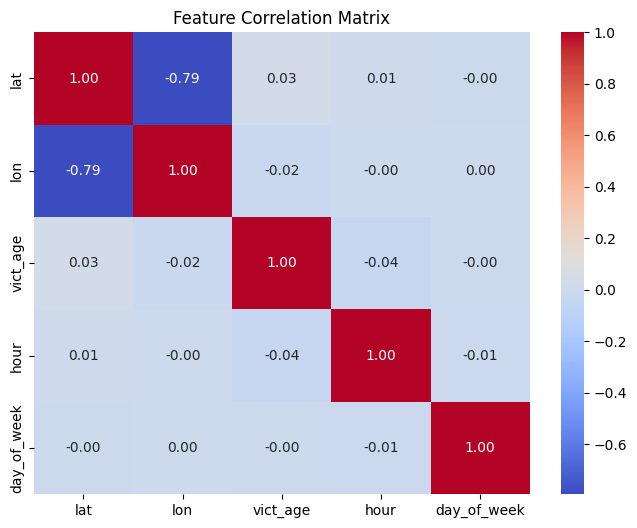

```python
numerical_features = ['lat', 'lon', 'vict_age', 'hour', 'day_of_week']
correlation_matrix = data_filt[numerical_features].corr()  # Compute the correlation matrix

# Plot the correlation matrix as a heatmap
plt.figure(figsize=(8, 6))
sns.heatmap(correlation_matrix, annot=True, fmt=".2f", cmap="coolwarm", cbar=True)
plt.title('Feature Correlation Matrix')
plt.show()
```

The Correlation matrix helps us identify features that are correlated, i.e. the variables have a strong linear relationship with each other. In our data, Latitude and Longitude have a strong correlation, as expected. However, the other features are mostly uncorrelated. So, the effect of one feature will not affect the other. Having highly correlated features is not recommended, as it will lead to providing similar or redundant information for the model, thereby confusing it.

```python
from sklearn.model_selection import train_test_split
from sklearn.preprocessing import OneHotEncoder

# Encode categorical features (e.g., 'crm_cd_desc', 'premis_desc', 'area_name')
categorical_features = ['crm_cd_desc', 'premis_desc', 'area_name', 'time_bin']
numerical_features = ['lat', 'lon', 'vict_age', 'hour', 'day_of_week']

# One-hot encode categorical features
encoder = OneHotEncoder(handle_unknown='ignore')
encoded_cats = encoder.fit_transform(data_filt[categorical_features])

# Combine numerical features and encoded categorical features
import scipy
X = scipy.sparse.hstack((encoded_cats, data_filt[numerical_features].values))

# Target variable
from sklearn.preprocessing import LabelEncoder
label_encoder = LabelEncoder()
y = label_encoder.fit_transform(data_filt['vict_descent'])
target_names = label_encoder.classes_
# Train-test split
X_train, X_test, y_train, y_test = train_test_split(X, y, test_size=0.2, random_state=42)

from sklearn.ensemble import RandomForestClassifier
from sklearn.metrics import accuracy_score, classification_report

# Initialize Random Forest
rf_model = RandomForestClassifier(n_estimators=50, random_state=42, n_jobs=-1)

# Train the model
rf_model.fit(X_train, y_train)

# Predict on the test set
y_pred = rf_model.predict(X_test)
labels = range(len(target_names))
# Evaluate the model
accuracy = accuracy_score(y_test, y_pred)
print(f"Accuracy: {accuracy * 100:.2f}%")
print("\nClassification Report:")
# print(classification_report(y_test, y_pred, target_names=label_encoder.classes_))
print(classification_report(y_test, y_pred, target_names=target_names, labels=labels))
```

```
Accuracy: 62.54%

Classification Report:
                                precision    recall  f1-score   support

American Indian/Alaskan Native       0.18      0.04      0.07        98
                  Asian Indian       0.00      0.00      0.00        65
                         Black       0.48      0.38      0.43     12922
                     Cambodian       0.00      0.00      0.00         9
                       Chinese       0.11      0.02      0.04       466
                      Filipino       0.07      0.01      0.02       468
                     Guamanian       0.00      0.00      0.00         4
                      Hawaiian       0.50      0.08      0.13        26
        Hispanic/Latin/Mexican       0.58      0.72      0.64     28599
                      Japanese       0.16      0.02      0.04       150
                        Korean       0.16      0.04      0.07       563
                       Laotian       0.00      0.00      0.00         7
                         Other       0.38      0.15      0.21      7328
                   Other Asian       0.23      0.06      0.09      2071
              Pacific Islander       0.00      0.00      0.00        29
                        Samoan       0.00      0.00      0.00         5
                       Unknown       0.93      0.95      0.94     22336
                    Vietnamese       0.04      0.01      0.02       106
                         White       0.50      0.56      0.53     18261

                      accuracy                           0.63     93513
                     macro avg       0.23      0.16      0.17     93513
                  weighted avg       0.60      0.63      0.60     93513
```

## **Classification Metrics Summary**

#### **Insights**

- The model well for high-support categories such as **Hispanic**, **White**, and **Unknown** while poor in smaller ones.
- The imbalanced class distribution influences the overall performance significantly, especially for the underrepresented descent categories.

Moreover, other techniques like **class weighting**, **oversampling /undersampling** - or using other models might help in making decent predictions for low-support categories.

### **Confusion Matrix**

[figure not shown]

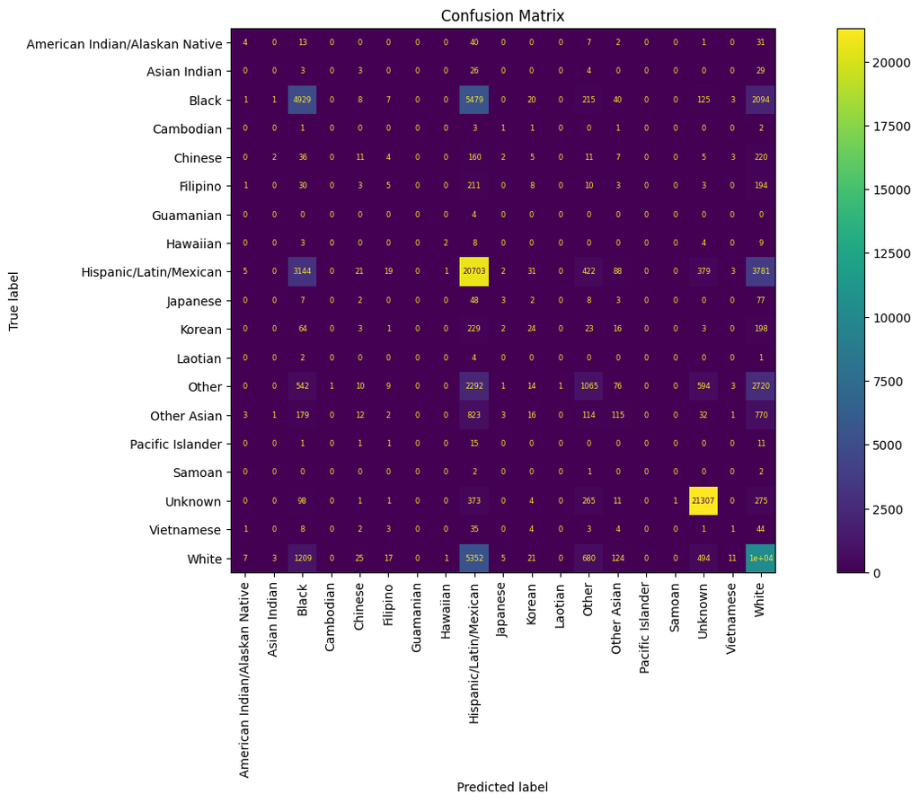

```python
unique_labels = np.unique(np.concatenate((y_test, y_pred)))
# Calculate the confusion matrix
conf_matrix = confusion_matrix(y_test, y_pred, labels=unique_labels)

fig, ax = plt.subplots(figsize=(18, 8))
disp = ConfusionMatrixDisplay(confusion_matrix=conf_matrix, display_labels=[label_encoder.classes_[i] for i in unique_labels])
disp.plot(cmap='viridis', xticks_rotation=90, ax=ax)  # Use a colormap for a better visual representation of the accuracy in prediction
for text in disp.ax_.texts:
    text.set_fontsize(6)
plt.title('Confusion Matrix')
plt.show()
```

#### **Conclusion on the Model**

The model performs well for larger categories but struggles with smaller or underrepresented groups, as seen by the low precision and recall for these categories. It would be better to balance the classes using oversampling or weighted classification.

***However, our purpose in building this model was not to create an accurate victim descent predictor. Instead, we want to study the features and their importance w.r.t the victim's descent to see if there's any correlation.***

## **Feature Importance**

```
                                Feature  Importance
464                            vict_age    0.259743
463                                 lon    0.124082
462                                 lat    0.123544
465                                hour    0.074199
466                         day_of_week    0.069797
130        crm_cd_desc_VEHICLE - STOLEN    0.036610
397                  premis_desc_STREET    0.011387
386  premis_desc_SINGLE FAMILY DWELLING    0.010603
458                  time_bin_Afternoon    0.008784
460                    time_bin_Morning    0.007776
```

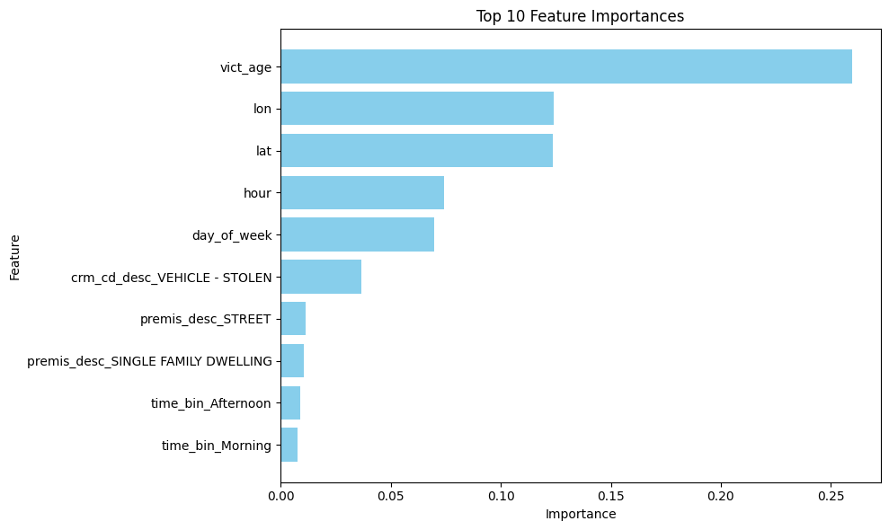

```python
# Get feature importance from the Random Forest model
feature_importances = rf_model.feature_importances_

# Get the feature names from the OneHotEncoder and numerical features
categorical_feature_names = encoder.get_feature_names_out(categorical_features)
numerical_feature_names = numerical_features
all_feature_names = np.concatenate([categorical_feature_names, numerical_feature_names])

# Combine feature importance with feature names into a DataFrame
feature_importance_df = pd.DataFrame({
    'Feature': all_feature_names,
    'Importance': feature_importances
})

# Sort by importance (descending)
feature_importance_df = feature_importance_df.sort_values(by='Importance', ascending=False)

# Display the top 10 features
print(feature_importance_df.head(10))

# Plot the top 10 most important features
plt.figure(figsize=(10, 6))
plt.barh(feature_importance_df['Feature'].head(10), feature_importance_df['Importance'].head(10), color='skyblue')
plt.gca().invert_yaxis()  # Invert y-axis to show the highest importance at the top
plt.title('Top 10 Feature Importances')
plt.xlabel('Importance')
plt.ylabel('Feature')
plt.tight_layout()
plt.show()
```

### **Feature Importance Observations**

The feature importance plot describes the features with the most significant impact responsible for the prediction of **victim descent**. Below are the key inferences:

### **Top Features**

1. **`vict_age`** (Victim Age):
   - The most important feature in the model.
   - Indicates that the age of the victim has a strong correlation with their descent. Certain age groups might be more prevalent in specific communities or targeted differently.
2. **`lon` (Longitude) and `lat` (Latitude):
   - Geographic location is critical, suggesting that crime hotspots or regional demographic distributions play a significant role in predicting victim descent.
3. **`hour` Time of Day:
   - Time of occurrence influences forecasts, maybe due to time-dependent criminal activities and, in turn, dependence of community activity on the time of day.
4. **`day_of_week`**:
   - Specific days may show a trend associated with certain descents, which may be a manifestation of cultural, social, or work-related practices.

### **Categorical Features**

1. **`crm_cd_desc_VEHICLE - STOLEN`**:
- Indicates that a specific crime type (`Vehicle Stolen`) has some importance in predicting victim descent. Certain communities might be disproportionately affected by such crimes.
2. **`premis_desc_STREET`** and **`premis_desc_SINGLE FAMILY DWELLING`**:
   - The premises where the crime occurred (e.g., streets or residential areas) hold predictive value, hinting at correlations between residential patterns and descent categories.
3. **`time_bin_Afternoon`** and **`time_bin_Morning`**:
- Time bins give us aggregated temporal patterns that may be different for specific communities or types of crime.

### **General Observations**

- **Numerical Features Dominate**:
  - Continuous variables such as age, latitude, and longitude are the most contributing features, which indicates their direct relationship with the target variable.
- **Categorical Features Are Secondary**:
  - Though the contribution of categorical features is less, the inclusion of these features adds nuance to specific crime types and patterns.

This analysis presents helps us with some correlation between the features and the descent of the victim in crimes. ***However, it is import to note that Correlation is not Causation. These features might be indirectly related, for which we might not have the information.***

# **Part 6- Conclusion**

These insights provide a foundation for further investigation and actionable recommendations to address crime patterns in Los Angeles.

## **Scope for Future Analysis**

1. **Geospatial Trends**:
   - Perform a detailed analysis of crime hotspots using geographic coordinates (lat/lon) to identify high-risk areas.
2. **Temporal Patterns**:
   - Investigate seasonal and hourly trends in crime occurrence to uncover time-based patterns.
3. **Social Factors**:
   - Incorporate socioeconomic data to study the influence of external factors on crime rates.

## **Resources:**

1. Data Extraction
- [catalog.data.gov](https://catalog.data.gov/dataset/crime-data-from-2020-to-present)
- [data.lacity.org](https://data.lacity.org/Public-Safety/Crime-Data-from-2020-to-Present/2nrs-mtv8/about_data)
- [support.socrata.com](https://support.socrata.com/hc/en-us/articles/202949268-How-to-query-more-than-1000-rows-of-a-dataset)
2. Data Processing EDA, Visualizations
- [MatPlotLib Documentation](https://matplotlib.org/stable/index.html)
- [EDA Using Python Functions](https://www.digitalocean.com/community/tutorials/exploratory-data-analysis-python)
3. Modelling, feature Importance
- [Random Forest- sklearn](https://scikit-learn.org/stable/modules/generated/sklearn.ensemble.RandomForestClassifier.html)
- [Random Forest from Scratch](https://machinelearningmastery.com/implement-random-forest-scratch-python/)
- [Feature Importance](https://machinelearningmastery.com/calculate-feature-importance-with-python/)
- [Confusion Matrix](https://www.v7labs.com/blog/confusion-matrix-guide)